# WASH Benefits RCT analysis- Shigella

# Quantitative IWAS

## MeanIWAS

Compare groups by meanIWAS, per pathogen

```r
#------------------------------
mean1 <- dpath2 %>%
  group_by(clusterid,childid,SampleID, tx, visit) %>%
  summarize(mean_iwas = mean_IWAS,
            .groups = "drop")
```

Estimate mean and 95% CIs for meanIwas at each visit bootstrap resample clusters to get the correct 95% CIs

```r
#----------------------------------
# estimate average meanIWAs by visit and
# group.
#----------------------------------
est_mu <- mean1 %>%
  group_by(visit,tx) %>%
  summarize(nobs = n(),
            mean_iwas = mean(mean_iwas),
            .groups = "drop")

#----------------------------------
# Bootstrap resample clusters
# to get the correct 95% CIs that account
# for repeated measures
#----------------------------------
set.seed(89326)
# create a bootstrap sampling frame
# resampling clusters with replacement
breps <- 1000
clids <- unique(mean1$clusterid)
bsamp <- matrix(sample(clids, size = breps*length(clids),replace=TRUE),nrow=length(clids),ncol=breps)

boot <- foreach(bi = 1:breps, .combine = rbind) %dopar% {
  # draw the bootstrap dataset,
  # due to repeated measures in the meaniwas dataset, this
  # is likely a many-to-many join since clusters could be sampled
  # more than once! (if not bootstrapping, would be one-to-many)
  di <- left_join(data.frame(clusterid = bsamp[,bi]), mean1,
                  join_by(clusterid), relationship = "many-to-many") %>%
    group_by(visit,tx) %>%
    summarize(nobs = n(),
              mean_iwas = mean(mean_iwas),
              .groups = "drop") %>%
    mutate(brep=bi)
  return(di[c("brep","visit","tx","mean_iwas")])
}

#----------------------------------
# estimate percentile 95% CIs for
# the meanIWAS by visit and group
# identify the 2.5% and 97.5% tiles
# of the bootstrap distribution
#----------------------------------
boot_ci <- boot %>%
  group_by(visit, tx) %>%
  mutate(min95 = quantile(mean_iwas,probs = 0.025),
         max95 = quantile(mean_iwas,probs = 0.975)) %>%
  slice(1) %>%
  select(visit,tx,min95,max95)
# join to the means
est_mu_visit <- est_mu %>%
  left_join(boot_ci, join_by(visit, tx))
```

```r
kbl(est_mu_visit, digits=3, caption = "MeanIWAS by visit and treatment group") %>%
  kable_styling(bootstrap_options = "striped")
```

MeanIWAS by visit and treatment group

| visit | tx | nobs | mean_iwas | min95 | max95 |
| --- | --- | --- | --- | --- | --- |
| Visit 1 | Control | 60 | -0.059 | -0.109 | -0.007 |
| Visit 1 | Intervention | 60 | -0.055 | -0.080 | -0.023 |
| Visit 2 | Control | 60 | -0.163 | -0.196 | -0.131 |
| Visit 2 | Intervention | 60 | -0.147 | -0.183 | -0.115 |
| Visit 3 | Control | 60 | -0.149 | -0.186 | -0.110 |
| Visit 3 | Intervention | 60 | -0.103 | -0.138 | -0.072 |

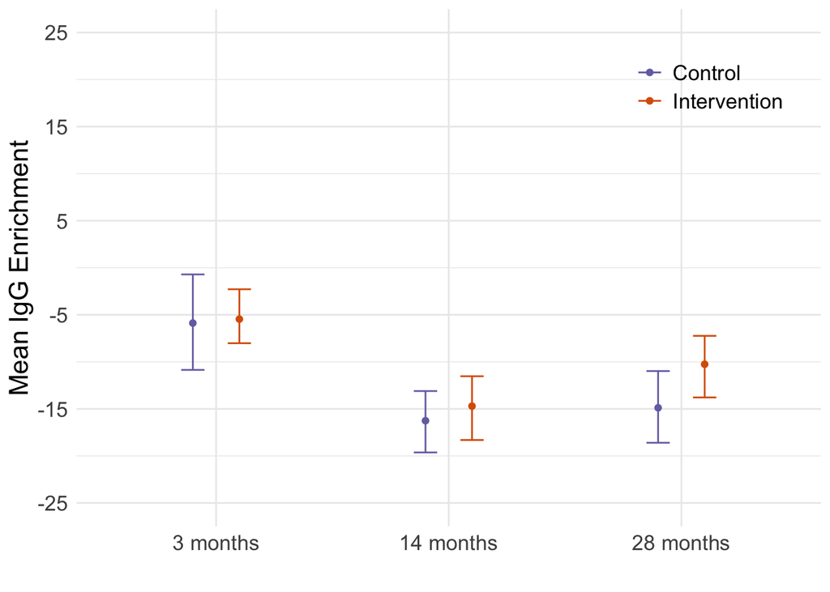

```r
#----------------------------------
# plot mean_iwas by visit
# and group
#----------------------------------
pcols <- brewer.pal(3,"Dark2")[c(3,2)]
plot_meaniwas_visit <- ggplot(est_mu_visit, aes(x = visit, color = tx)) +
  geom_errorbar(aes(ymin=min95,ymax=max95), position=position_nudge(x=c(-0.1,0.1)), width=0.1) +
  geom_point(aes(y=mean_iwas), position=position_nudge(x=c(-0.1,0.1))) +
  scale_color_manual(values=pcols) +
  scale_y_continuous(breaks=seq(-0.25,0.25,by=0.1),labels=seq(-0.25,0.25,by=0.1)*100) +
  coord_cartesian(ylim = c(-0.25,0.25)) +
  labs(x="",y="Mean IgG Enrichment") +
  theme_minimal() +
  theme(text = element_text(size = 16),
        legend.position = c(0.85, 0.85),
        legend.title=element_blank()) +
  scale_x_discrete(labels = wrapped_labels)
plot_meaniwas_visit
```

Collapse data from visits 2 and 3 per the pre-specified analysis plan. Estimate means, 95% CIs, along with differences and ratios

```r
#----------------------------------
# limit to visits 2, 3
#----------------------------------
mean2 <- mean1 %>%
  filter(visit %in% c("Visit 2","Visit 3"))
#----------------------------------
# estimate mean meaniwas by
# group.  This and bootstrap below
# is identical to estimation of means
# above, but does not stratify by visit
# (pools data over visits 2, 3)
#----------------------------------
ests_by_tx <- mean2 %>%
  group_by(tx) %>%
  summarize(nobs = n(),
            mean_iwas = mean(mean_iwas),
            .groups = "drop")
```

```r
#----------------------------------
# estimate the difference in
# meanIWAS using a linear regression model
# with robust SEs at the cluster level
# save estimates, 95% CI, and P-value
#----------------------------------
fit_iwas_diff <- glm(mean_iwas ~ tx, data=mean2, family=gaussian(link="identity"))
(fit_iwas_diff_rb <- coeftest(fit_iwas_diff, vcov. = vcovCL(fit_iwas_diff, cluster=mean2$clusterid)))
```

```
##
## z test of coefficients:
##
##                 Estimate Std. Error z value Pr(>|z|)
## (Intercept)    -0.155683   0.016778 -9.2790   <2e-16 ***
## txIntervention  0.030863   0.021553  1.4319   0.1522
## ---
## Signif. codes:  0 '***' 0.001 '**' 0.01 '*' 0.05 '.' 0.1 ' ' 1
```

```r
iwas_diff <- fit_iwas_diff_rb[2,1]
iwas_diff_se <- fit_iwas_diff_rb[2,2]
iwas_diff_min95 <- iwas_diff - 1.96*iwas_diff_se
iwas_diff_max95 <- iwas_diff + 1.96*iwas_diff_se
iwas_diff_p <- fit_iwas_diff_rb[2,4]

#----------------------------------
# estimate robust 95% CIs for
# mean_iwas by group from
# the model fit. Equivalent to
# bootstrap above (by visit), but faster
#----------------------------------
mu0 <- fit_iwas_diff_rb[1,1]
mu0_se <- fit_iwas_diff_rb[1,2]
mu0_min95 <- mu0 - 1.96*mu0_se
mu0_max95 <- mu0 + 1.96*mu0_se
mu1 <- fit_iwas_diff_rb[1,1]+fit_iwas_diff_rb[2,1]
# SE of mu1= sqrt of variance of the linear combination of intercept + tx
# the linear combination of coefficiencts is matrix-multiplied against
# the robust var-covariance matrix estimated above
mu1_se <- sqrt( t(c(1,1)) %*% vcovCL(fit_iwas_diff, cluster=mean2$clusterid) %*% c(1,1) )
mu1_min95 <- mu1 - 1.96*mu1_se
mu1_max95 <- mu1 + 1.96*mu1_se

#----------------------------------
# estimate the ratio in
# mean_iwas using a linear regression model
# with robust SEs at the cluster level
#----------------------------------
fit_iwas_ratio <- glm(mean_iwas ~ tx, data=mean2, family=gaussian(link="identity"))
(fit_iwas_ratio_rb <- coeftest(fit_iwas_ratio, vcov. = vcovCL(fit_iwas_ratio, cluster=mean2$clusterid)))
```

```
##
## z test of coefficients:
##
##                 Estimate Std. Error z value Pr(>|z|)
## (Intercept)    -0.155683   0.016778 -9.2790   <2e-16 ***
## txIntervention  0.030863   0.021553  1.4319   0.1522
## ---
## Signif. codes:  0 '***' 0.001 '**' 0.01 '*' 0.05 '.' 0.1 ' ' 1
```

```r
logiwas_ratio <- fit_iwas_ratio_rb[2,1]
logiwas_ratio_se <- fit_iwas_ratio_rb[2,2]
iwas_ratio <- exp(logiwas_ratio)
iwas_ratio_min95 <- exp(logiwas_ratio - 1.96*logiwas_ratio_se)
iwas_ratio_max95 <- exp(logiwas_ratio + 1.96*logiwas_ratio_se)
iwas_ratio_p <- fit_iwas_ratio_rb[2,4]


#----------------------------------
# combine results into a single
# data frame
#----------------------------------
ests_by_tx2 <- ests_by_tx
ests_by_tx2$mean_iwas_min95 <- c(mu0_min95,mu1_min95)
ests_by_tx2$mean_iwas_max95 <- c(mu0_max95,mu1_max95)
ests_by_tx2$iwas_diff <- c(NA,iwas_diff)
ests_by_tx2$iwas_diff_min95 <- c(NA,iwas_diff_min95)
ests_by_tx2$iwas_diff_max95 <- c(NA,iwas_diff_max95)
ests_by_tx2$iwas_diff_p <- c(NA,iwas_diff_p)
ests_by_tx2$iwas_ratio <- c(NA,iwas_ratio)
ests_by_tx2$iwas_ratio_min95 <- c(NA,iwas_ratio_min95)
ests_by_tx2$iwas_ratio_max95 <- c(NA,iwas_ratio_max95)
ests_by_tx2$iwas_ratio_p <- c(NA,iwas_ratio_p)
```

```r
#----------------------------------
# create formatted versions
#----------------------------------
ests_by_tx3 <- ests_by_tx2 %>%
  mutate(meaniwas_print = paste0(sprintf("%3.2f",mean_iwas), " (",
                                 sprintf("%3.2f",mean_iwas_min95), ", ",
                                 sprintf("%3.2f",mean_iwas_max95), ") ")
  ) %>%
  mutate(iwas_diff_print = paste0(sprintf("%3.2f",iwas_diff)," (",
                                 sprintf("%1.1f",iwas_diff_min95),", ",
                                 sprintf("%1.1f",iwas_diff_max95),")")
  ) %>%
  mutate(iwas_ratio_print = paste0(sprintf("%3.2f",iwas_ratio)," (",
                                 sprintf("%3.2f",iwas_ratio_min95),", ",
                                 sprintf("%3.2f",iwas_ratio_max95),")")
  ) %>%
  select(tx,nobs,meaniwas_print,iwas_diff_print,iwas_ratio_print,iwas_ratio_p)

# set formatted print vals to missing again for cleaner display
ests_by_tx3$iwas_diff_print[ests_by_tx$tx=="Control"] <- NA
ests_by_tx3$iwas_ratio_print[ests_by_tx$tx=="Control"] <- NA

options(knitr.kable.NA = '')
kbl(ests_by_tx3, digits=3, caption = "meanIWAS, comparison of groups. Estimates based on 60 children in each group measured twice at median ages 14 and 28 months. 95% CIs and P-values account for repeated measures within children and clusters using robust SEs", col.names = c("Group","N","mean_IWAS (95% CI)","iwas_diff (95% CI)","iwas_ratio (95% CI)","P-value")) %>%
  kable_styling(bootstrap_options = "striped")
```

meanIWAS, comparison of groups. Estimates based on 60 children in each group measured twice at median ages 14 and 28 months. 95% CIs and P-values account for repeated measures within children and clusters using robust SEs

| Group | N | mean_IWAS (95% CI) | iwas_diff (95% CI) | iwas_ratio (95% CI) | P-value |
| --- | --- | --- | --- | --- | --- |
| Control | 120 | -0.16 (-0.19, -0.12) |  |  |  |
| Intervention | 120 | -0.12 (-0.15, -0.10) | 0.03 (-0.0, 0.1) | 1.03 (0.99, 1.08) | 0.152 |

## MaxIWAS

Compare groups by maxIWAS, per pathogen

```r
#------------------------------
max1 <- dpath2 %>%
  group_by(clusterid,childid,SampleID, tx, visit) %>%
  summarize(max_iwas = max_IWAS,
            .groups = "drop")
```

Estimate mean and 95% CIs for maxIWAS at each visit bootstrap resample clusters to get the correct 95% CIs

```r
#----------------------------------
# estimate average maxIWAs by visit and
# group.
#----------------------------------
est_mu <- max1 %>%
  group_by(visit,tx) %>%
  summarize(nobs = n(),
            avg_max_iwas = mean(max_iwas),
            .groups = "drop")

#----------------------------------
# Bootstrap resample clusters
# to get the correct 95% CIs that account
# for repeated measures
#----------------------------------
set.seed(89326)
# create a bootstrap sampling frame
# resampling clusters with replacement
breps <- 1000
clids <- unique(max1$clusterid)
bsamp <- matrix(sample(clids, size = breps*length(clids),replace=TRUE),nrow=length(clids),ncol=breps)

boot <- foreach(bi = 1:breps, .combine = rbind) %dopar% {
  # draw the bootstrap dataset,
  # due to repeated measures in the max_iwas dataset, this
  # is likely a many-to-many join since clusters could be sampled
  # more than once! (if not bootstrapping, would be one-to-many)
  di <- left_join(data.frame(clusterid = bsamp[,bi]), max1,
                  join_by(clusterid), relationship = "many-to-many") %>%
    group_by(visit,tx) %>%
    summarize(nobs = n(),
              avg_max_iwas = mean(max_iwas),
              .groups = "drop") %>%
    mutate(brep=bi)
  return(di[c("brep","visit","tx","avg_max_iwas")])
}

#----------------------------------
# estimate percentile 95% CIs for
# the avg_max_iwas by visit and group
# identify the 2.5% and 97.5% tiles
# of the bootstrap distribution
#----------------------------------
boot_ci <- boot %>%
  group_by(visit, tx) %>%
  mutate(min95 = quantile(avg_max_iwas,probs = 0.025),
         max95 = quantile(avg_max_iwas,probs = 0.975)) %>%
  slice(1) %>%
  select(visit,tx,min95,max95)
# join to the means
est_mu_visit <- est_mu %>%
  left_join(boot_ci, join_by(visit, tx))
```

```r
kbl(est_mu_visit, digits=3, caption = "MaxIWAS by visit and treatment group") %>%
  kable_styling(bootstrap_options = "striped")
```

MaxIWAS by visit and treatment group

| visit | tx | nobs | avg_max_iwas | min95 | max95 |
| --- | --- | --- | --- | --- | --- |
| Visit 1 | Control | 60 | 6.843 | 5.887 | 7.677 |
| Visit 1 | Intervention | 60 | 6.685 | 5.987 | 7.598 |
| Visit 2 | Control | 60 | 3.564 | 3.240 | 4.025 |
| Visit 2 | Intervention | 60 | 3.531 | 3.063 | 3.943 |
| Visit 3 | Control | 60 | 4.315 | 3.755 | 4.964 |
| Visit 3 | Intervention | 60 | 4.127 | 3.629 | 4.665 |

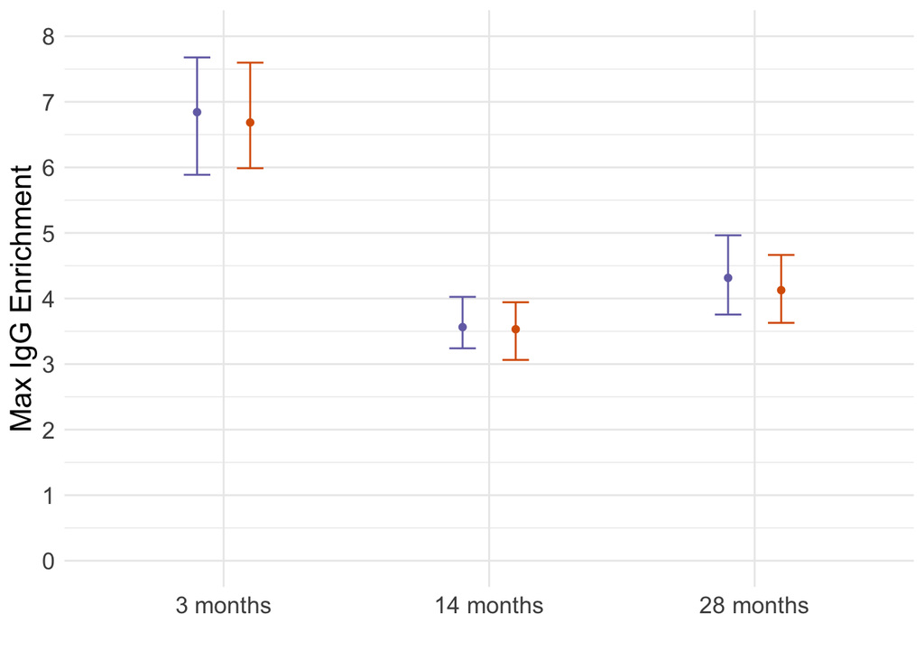

```r
#----------------------------------
# plot max_iwas by visit
# and group
#----------------------------------
pcols <- brewer.pal(3,"Dark2")[c(3,2)]
plot_maxiwas_visit <- ggplot(est_mu_visit, aes(x = visit, color = tx)) +
  geom_errorbar(aes(ymin=min95,ymax=max95), position=position_nudge(x=c(-0.1,0.1)), width=0.1) +
  geom_point(aes(y=avg_max_iwas), position=position_nudge(x=c(-0.1,0.1))) +
  scale_color_manual(values=pcols) +
  scale_y_continuous(breaks=seq(0,8,by=1),labels=seq(0,8,by=1)) +
  coord_cartesian(ylim = c(0,8)) +
  labs(x="",y="Max IgG Enrichment") +
  theme_minimal() +
  theme(text = element_text(size = 16),
        legend.position = "none") +
  scale_x_discrete(labels = wrapped_labels)

plot_maxiwas_visit
```

Collapse data from visits 2 and 3 per the pre-specified analysis plan. Estimate means, 95% CIs, along with differences and ratios

```r
#----------------------------------
# limit to visits 2, 3
#----------------------------------
max2 <- max1 %>%
  filter(visit %in% c("Visit 2","Visit 3"))
#----------------------------------
# estimate mean maxiwas by
# group.  This and bootstrap below
# is identical to estimation of means
# above, but does not stratify by visit
# (pools data over visits 2, 3)
#----------------------------------
ests_by_tx <- max2 %>%
  group_by(tx) %>%
  summarize(nobs = n(),
            avg_max_iwas = mean(max_iwas),
            .groups = "drop")
```

```r
#----------------------------------
# estimate the difference in
# maxIWAS using a linear regression model
# with robust SEs at the cluster level
# save estimates, 95% CI, and P-value
#----------------------------------
fit_iwas_diff <- glm(max_iwas ~ tx, data=max2, family=gaussian(link="identity"))
(fit_iwas_diff_rb <- coeftest(fit_iwas_diff, vcov. = vcovCL(fit_iwas_diff, cluster=mean2$clusterid)))
```

```
##
## z test of coefficients:
##
##                Estimate Std. Error z value Pr(>|z|)
## (Intercept)     3.93939    0.19580 20.1191   <2e-16 ***
## txIntervention -0.11000    0.27146 -0.4052   0.6853
## ---
## Signif. codes:  0 '***' 0.001 '**' 0.01 '*' 0.05 '.' 0.1 ' ' 1
```

```r
iwas_diff <- fit_iwas_diff_rb[2,1]
iwas_diff_se <- fit_iwas_diff_rb[2,2]
iwas_diff_min95 <- iwas_diff - 1.96*iwas_diff_se
iwas_diff_max95 <- iwas_diff + 1.96*iwas_diff_se
iwas_diff_p <- fit_iwas_diff_rb[2,4]

#----------------------------------
# estimate robust 95% CIs for
# max_iwas by group from
# the model fit. Equivalent to
# bootstrap above (by visit), but faster
#----------------------------------
mu0 <- fit_iwas_diff_rb[1,1]
mu0_se <- fit_iwas_diff_rb[1,2]
mu0_min95 <- mu0 - 1.96*mu0_se
mu0_max95 <- mu0 + 1.96*mu0_se
mu1 <- fit_iwas_diff_rb[1,1]+fit_iwas_diff_rb[2,1]
# SE of mu1= sqrt of variance of the linear combination of intercept + tx
# the linear combination of coefficiencts is matrix-multiplied against
# the robust var-covariance matrix estimated above
mu1_se <- sqrt( t(c(1,1)) %*% vcovCL(fit_iwas_diff, cluster=mean2$clusterid) %*% c(1,1) )
mu1_min95 <- mu1 - 1.96*mu1_se
mu1_max95 <- mu1 + 1.96*mu1_se

#----------------------------------
# estimate the ratio in
# max_iwas using a linear regression model
# with robust SEs at the cluster level
#----------------------------------
fit_iwas_ratio <- glm(max_iwas ~ tx, data=max2, family=gaussian(link="identity"))
(fit_iwas_ratio_rb <- coeftest(fit_iwas_ratio, vcov. = vcovCL(fit_iwas_ratio, cluster=mean2$clusterid)))
```

```
##
## z test of coefficients:
##
##                Estimate Std. Error z value Pr(>|z|)
## (Intercept)     3.93939    0.19580 20.1191   <2e-16 ***
## txIntervention -0.11000    0.27146 -0.4052   0.6853
## ---
## Signif. codes:  0 '***' 0.001 '**' 0.01 '*' 0.05 '.' 0.1 ' ' 1
```

```r
logiwas_ratio <- fit_iwas_ratio_rb[2,1]
logiwas_ratio_se <- fit_iwas_ratio_rb[2,2]
iwas_ratio <- exp(logiwas_ratio)
iwas_ratio_min95 <- exp(logiwas_ratio - 1.96*logiwas_ratio_se)
iwas_ratio_max95 <- exp(logiwas_ratio + 1.96*logiwas_ratio_se)
iwas_ratio_p <- fit_iwas_ratio_rb[2,4]


#----------------------------------
# combine results into a single
# data frame
#----------------------------------
ests_by_tx2 <- ests_by_tx
ests_by_tx2$max_iwas_min95 <- c(mu0_min95,mu1_min95)
ests_by_tx2$max_iwas_max95 <- c(mu0_max95,mu1_max95)
ests_by_tx2$iwas_diff <- c(NA,iwas_diff)
ests_by_tx2$iwas_diff_min95 <- c(NA,iwas_diff_min95)
ests_by_tx2$iwas_diff_max95 <- c(NA,iwas_diff_max95)
ests_by_tx2$iwas_diff_p <- c(NA,iwas_diff_p)
ests_by_tx2$iwas_ratio <- c(NA,iwas_ratio)
ests_by_tx2$iwas_ratio_min95 <- c(NA,iwas_ratio_min95)
ests_by_tx2$iwas_ratio_max95 <- c(NA,iwas_ratio_max95)
ests_by_tx2$iwas_ratio_p <- c(NA,iwas_ratio_p)
```

```r
#----------------------------------
# create formatted versions
#----------------------------------
ests_by_tx3 <- ests_by_tx2 %>%
  mutate(maxiwas_print = paste0(sprintf("%3.2f",avg_max_iwas), " (",
                                 sprintf("%3.2f",max_iwas_min95), ", ",
                                 sprintf("%3.2f",max_iwas_max95), ") ")
  ) %>%
  mutate(iwas_diff_print = paste0(sprintf("%3.2f",iwas_diff)," (",
                                 sprintf("%1.1f",iwas_diff_min95),", ",
                                 sprintf("%1.1f",iwas_diff_max95),")")
  ) %>%
  mutate(iwas_ratio_print = paste0(sprintf("%3.2f",iwas_ratio)," (",
                                 sprintf("%3.2f",iwas_ratio_min95),", ",
                                 sprintf("%3.2f",iwas_ratio_max95),")")
  ) %>%
  select(tx,nobs,maxiwas_print,iwas_diff_print,iwas_ratio_print,iwas_ratio_p)

# set formatted print vals to missing again for cleaner display
ests_by_tx3$iwas_diff_print[ests_by_tx$tx=="Control"] <- NA
ests_by_tx3$iwas_ratio_print[ests_by_tx$tx=="Control"] <- NA

options(knitr.kable.NA = '')
kbl(ests_by_tx3, digits=3, caption = "maxIWAS, comparison of groups. Estimates based on 60 children in each group measured twice at median ages 14 and 28 months. 95% CIs and P-values account for repeated measures within children and clusters using robust SEs", col.names = c("Group","N","max_IWAS (95% CI)","iwas_diff (95% CI)","iwas_ratio (95% CI)","P-value")) %>%
  kable_styling(bootstrap_options = "striped")
```

maxIWAS, comparison of groups. Estimates based on 60 children in each group measured twice at median ages 14 and 28 months. 95% CIs and P-values account for repeated measures within children and clusters using robust SEs

| Group | N | max_IWAS (95% CI) | iwas_diff (95% CI) | iwas_ratio (95% CI) | P-value |
| --- | --- | --- | --- | --- | --- |
| Control | 120 | 3.94 (3.56, 4.32) |  |  |  |
| Intervention | 120 | 3.83 (3.46, 4.20) | -0.11 (-0.6, 0.4) | 0.90 (0.53, 1.53) | 0.685 |

## Sera score

Compare groups by sera score, per pathogen

```r
#------------------------------
sera <- dpath2 %>%
  group_by(clusterid,childid,SampleID, tx, visit) %>%
  summarize(sera = sera,
            .groups = "drop")
```

Estimate mean and 95% CIs for sera score at each visit bootstrap resample clusters to get the correct 95% CIs

```r
#----------------------------------
# estimate average sera score by visit and
# group.
#----------------------------------
est_mu <- sera %>%
  group_by(visit,tx) %>%
  summarize(nobs = n(),
            mean_sera = mean(sera),
            .groups = "drop")

#----------------------------------
# Bootstrap resample clusters
# to get the correct 95% CIs that account
# for repeated measures
#----------------------------------
set.seed(89326)
# create a bootstrap sampling frame
# resampling clusters with replacement
breps <- 1000
clids <- unique(sera$clusterid)
bsamp <- matrix(sample(clids, size = breps*length(clids),replace=TRUE),nrow=length(clids),ncol=breps)

boot <- foreach(bi = 1:breps, .combine = rbind) %dopar% {
  # draw the bootstrap dataset,
  # due to repeated measures in the sera dataset, this
  # is likely a many-to-many join since clusters could be sampled
  # more than once! (if not bootstrapping, would be one-to-many)
  di <- left_join(data.frame(clusterid = bsamp[,bi]), sera,
                  join_by(clusterid), relationship = "many-to-many") %>%
    group_by(visit,tx) %>%
    summarize(nobs = n(),
              mean_sera = mean(sera),
              .groups = "drop") %>%
    mutate(brep=bi)
  return(di[c("brep","visit","tx","mean_sera")])
}

#----------------------------------
# estimate percentile 95% CIs for
# the mean_sera by visit and group
# identify the 2.5% and 97.5% tiles
# of the bootstrap distribution
#----------------------------------
boot_ci <- boot %>%
  group_by(visit, tx) %>%
  mutate(min95 = quantile(mean_sera,probs = 0.025),
         max95 = quantile(mean_sera,probs = 0.975)) %>%
  slice(1) %>%
  select(visit,tx,min95,max95)
# join to the means
est_mu_visit <- est_mu %>%
  left_join(boot_ci, join_by(visit, tx))
```

```r
kbl(est_mu_visit, digits=3, caption = "Sera Score by visit and treatment group") %>%
  kable_styling(bootstrap_options = "striped")
```

Sera Score by visit and treatment group

| visit | tx | nobs | mean_sera | min95 | max95 |
| --- | --- | --- | --- | --- | --- |
| Visit 1 | Control | 60 | 203.138 | 153.960 | 256.460 |
| Visit 1 | Intervention | 60 | 261.626 | 201.463 | 348.021 |
| Visit 2 | Control | 60 | 18.817 | 9.531 | 31.704 |
| Visit 2 | Intervention | 60 | 19.478 | 11.081 | 29.473 |
| Visit 3 | Control | 60 | 51.264 | 29.441 | 79.494 |
| Visit 3 | Intervention | 60 | 51.468 | 28.305 | 75.675 |

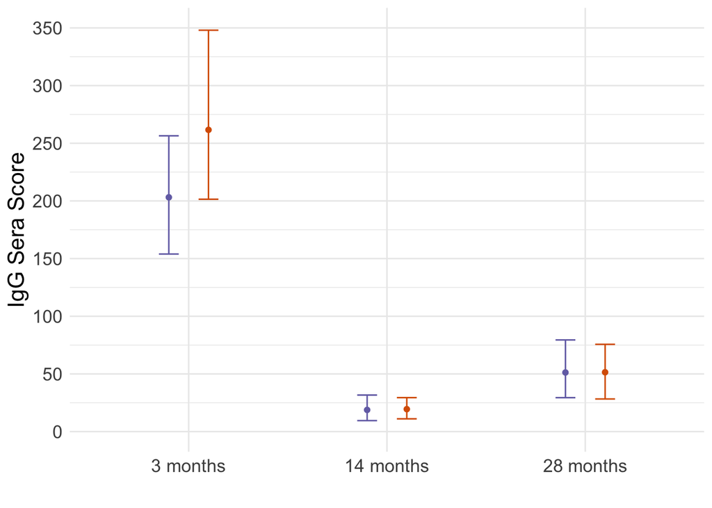

```r
#----------------------------------
# plot sera score by visit
# and group
#----------------------------------
pcols <- brewer.pal(3,"Dark2")[c(3,2)]
plot_sera_visit <- ggplot(est_mu_visit, aes(x = visit, color = tx)) +
  geom_errorbar(aes(ymin=min95,ymax=max95), position=position_nudge(x=c(-0.1,0.1)), width=0.1) +
  geom_point(aes(y=mean_sera), position=position_nudge(x=c(-0.1,0.1))) +
  scale_color_manual(values=pcols) +
  scale_y_continuous(breaks=seq(0,350,by=50),labels=seq(0,350,by=50)) +
  coord_cartesian(ylim = c(0,350)) +
  labs(x="",y="IgG Sera Score") +
  theme_minimal() +
  theme(text = element_text(size = 16),
        legend.position = "none") +
  scale_x_discrete(labels = wrapped_labels)

plot_sera_visit
```

Collapse data from visits 2 and 3 per the pre-specified analysis plan. Estimate means, 95% CIs, along with differences and ratios

```r
#----------------------------------
# limit to visits 2, 3
#----------------------------------
sera2 <- sera %>%
  filter(visit %in% c("Visit 2","Visit 3"))
#----------------------------------
# estimate mean sera score by
# group.  This and bootstrap below
# is identical to estimation of means
# above, but does not stratify by visit
# (pools data over visits 2, 3)
#----------------------------------
ests_by_tx <- sera2 %>%
  group_by(tx) %>%
  summarize(nobs = n(),
            mean_sera = mean(sera),
            .groups = "drop")
```

```r
#----------------------------------
# estimate the difference in
# sera score using a linear regression model
# with robust SEs at the cluster level
# save estimates, 95% CI, and P-value
#----------------------------------
fit_sera_diff <- glm(sera ~ tx, data=sera2, family=gaussian(link="identity"))
(fit_sera_diff_rb <- coeftest(fit_sera_diff, vcov. = vcovCL(fit_sera_diff, cluster=sera2$clusterid)))
```

```
##
## z test of coefficients:
##
##                Estimate Std. Error z value  Pr(>|z|)
## (Intercept)    35.04067    7.48277  4.6828 2.829e-06 ***
## txIntervention  0.43258   10.26721  0.0421    0.9664
## ---
## Signif. codes:  0 '***' 0.001 '**' 0.01 '*' 0.05 '.' 0.1 ' ' 1
```

```r
sera_diff <- fit_sera_diff_rb[2,1]
sera_diff_se <- fit_sera_diff_rb[2,2]
sera_diff_min95 <- sera_diff - 1.96*sera_diff_se
sera_diff_max95 <- sera_diff + 1.96*sera_diff_se
sera_diff_p <- fit_sera_diff_rb[2,4]

#----------------------------------
# estimate robust 95% CIs for
# sera score by group from
# the model fit. Equivalent to
# bootstrap above (by visit), but faster
#----------------------------------
mu0 <- fit_sera_diff_rb[1,1]
mu0_se <- fit_sera_diff_rb[1,2]
mu0_min95 <- mu0 - 1.96*mu0_se
mu0_max95 <- mu0 + 1.96*mu0_se
mu1 <- fit_sera_diff_rb[1,1]+fit_sera_diff_rb[2,1]
# SE of mu1= sqrt of variance of the linear combination of intercept + tx
# the linear combination of coefficiencts is matrix-multiplied against
# the robust var-covariance matrix estimated above
mu1_se <- sqrt( t(c(1,1)) %*% vcovCL(fit_sera_diff, cluster=sera2$clusterid) %*% c(1,1) )
mu1_min95 <- mu1 - 1.96*mu1_se
mu1_max95 <- mu1 + 1.96*mu1_se

#----------------------------------
# estimate the ratio in
# mean sera score using a linear regression model
# with robust SEs at the cluster level
#----------------------------------
fit_sera_ratio <- glm(sera ~ tx, data=sera2, family=gaussian(link="identity"))
(fit_sera_ratio_rb <- coeftest(fit_sera_ratio, vcov. = vcovCL(fit_sera_ratio, cluster=sera2$clusterid)))
```

```
##
## z test of coefficients:
##
##                Estimate Std. Error z value  Pr(>|z|)
## (Intercept)    35.04067    7.48277  4.6828 2.829e-06 ***
## txIntervention  0.43258   10.26721  0.0421    0.9664
## ---
## Signif. codes:  0 '***' 0.001 '**' 0.01 '*' 0.05 '.' 0.1 ' ' 1
```

```r
logsera_ratio <- fit_sera_ratio_rb[2,1]
logsera_ratio_se <- fit_sera_ratio_rb[2,2]
sera_ratio <- exp(logsera_ratio)
sera_ratio_min95 <- exp(logsera_ratio - 1.96*logsera_ratio_se)
sera_ratio_max95 <- exp(logsera_ratio + 1.96*logsera_ratio_se)
sera_ratio_p <- fit_sera_ratio_rb[2,4]


#----------------------------------
# combine results into a single
# data frame
#----------------------------------
ests_by_tx2 <- ests_by_tx
ests_by_tx2$sera_min95 <- c(mu0_min95,mu1_min95)
ests_by_tx2$sera_max95 <- c(mu0_max95,mu1_max95)
ests_by_tx2$sera_diff <- c(NA,sera_diff)
ests_by_tx2$sera_diff_min95 <- c(NA,sera_diff_min95)
ests_by_tx2$sera_diff_max95 <- c(NA,sera_diff_max95)
ests_by_tx2$sera_diff_p <- c(NA,sera_diff_p)
ests_by_tx2$sera_ratio <- c(NA,sera_ratio)
ests_by_tx2$sera_ratio_min95 <- c(NA,sera_ratio_min95)
ests_by_tx2$sera_ratio_max95 <- c(NA,sera_ratio_max95)
ests_by_tx2$sera_ratio_p <- c(NA,sera_ratio_p)
```

```r
#----------------------------------
# create formatted versions
#----------------------------------
ests_by_tx3 <- ests_by_tx2 %>%
  mutate(sera_print = paste0(sprintf("%3.2f",mean_sera), " (",
                                 sprintf("%3.2f",sera_min95), ", ",
                                 sprintf("%3.2f",sera_max95), ") ")
  ) %>%
  mutate(sera_diff_print = paste0(sprintf("%3.2f",sera_diff)," (",
                                 sprintf("%1.1f",sera_diff_min95),", ",
                                 sprintf("%1.1f",sera_diff_max95),")")
  ) %>%
  mutate(sera_ratio_print = paste0(sprintf("%3.2f",sera_ratio)," (",
                                 sprintf("%3.2f",sera_ratio_min95),", ",
                                 sprintf("%3.2f",sera_ratio_max95),")")
  ) %>%
  select(tx,nobs,sera_print,sera_diff_print,sera_ratio_print,sera_ratio_p)

# set formatted print vals to missing again for cleaner display
ests_by_tx3$sera_diff_print[ests_by_tx$tx=="Control"] <- NA
ests_by_tx3$sera_ratio_print[ests_by_tx$tx=="Control"] <- NA

options(knitr.kable.NA = '')
kbl(ests_by_tx3, digits=3, caption = "Sera Score, comparison of groups. Estimates based on 60 children in each group measured twice at median ages 14 and 28 months. 95% CIs and P-values account for repeated measures within children and clusters using robust SEs", col.names = c("Group","N","mean_sera (95% CI)","sera_diff (95% CI)","sera_ratio (95% CI)","P-value")) %>%
  kable_styling(bootstrap_options = "striped")
```

Sera Score, comparison of groups. Estimates based on 60 children in each group measured twice at median ages 14 and 28 months. 95% CIs and P-values account for repeated measures within children and clusters using robust SEs

| Group | N | mean_sera (95% CI) | sera_diff (95% CI) | sera_ratio (95% CI) | P-value |
| --- | --- | --- | --- | --- | --- |
| Control | 120 | 35.04 (20.37, 49.71) |  |  |  |
| Intervention | 120 | 35.47 (21.69, 49.25) | 0.43 (-19.7, 20.6) | 1.54 (0.00, 846245639.86) | 0.966 |

# Format aggregate plot for manuscript

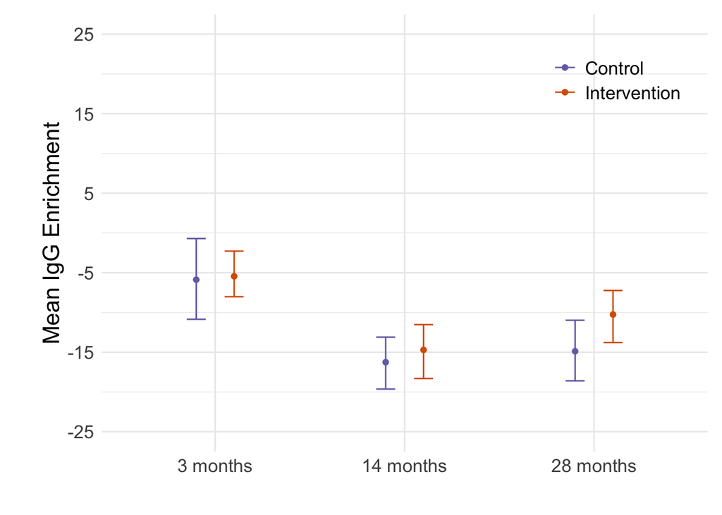

```r
# seroprevalence plot
p1 <- plot_seroprev_visit + theme(plot.margin = margin(15, 10, 10, 15))

# epitope hits plot
p2 <- plot_hits_by_visit + theme(plot.margin = margin(10, 10, 10, 15))

# mean IWAS
p3 <- plot_meaniwas_visit + theme(plot.margin = margin(10, 10, 10, 30))
p3
```

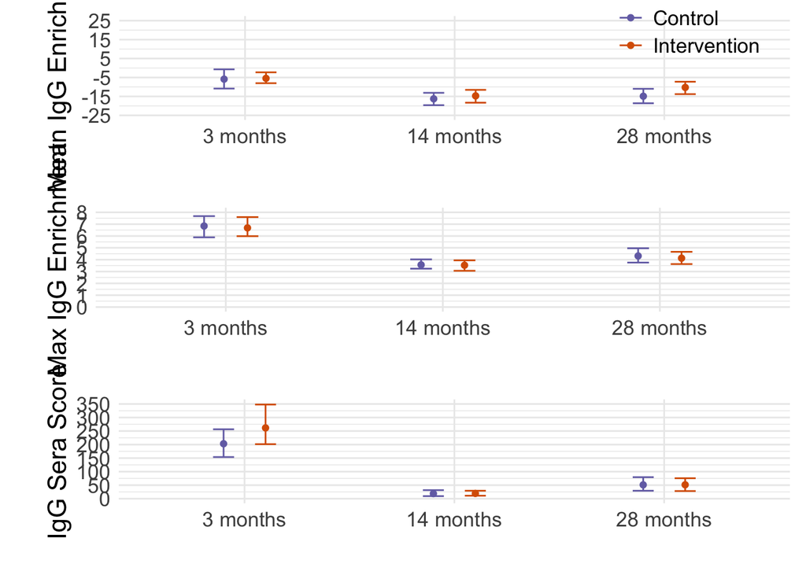

```r
# max IWAS
p4 <- plot_maxiwas_visit + theme(plot.margin = margin(10, 10, 10, 30))

# sera score
p5 <- plot_sera_visit + theme(plot.margin = margin(10, 10, 10, 30))

l_panel <- plot_grid(p3, p4, p5, ncol = 1)
l_panel
```

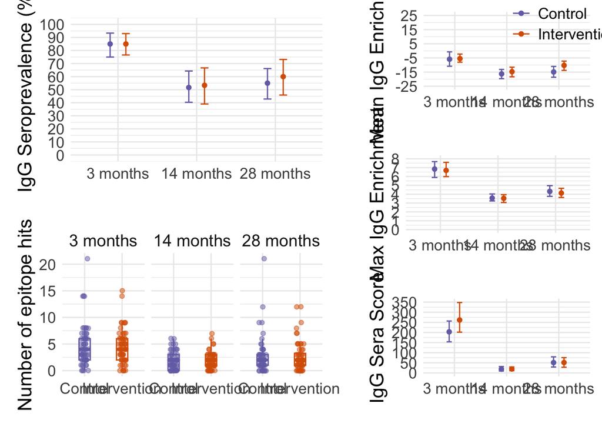

```r
r_panel <- plot_grid(p1, p2, ncol = 1)
# plot two on left and three smaller ones on right
fig2 <- plot_grid(r_panel, l_panel, align = 'hv', ncol = 2, rel_widths = c(1.25, 1))
fig2
```

```r
fig2_out <- ggdraw(fig2) +
  draw_label("A)", x = 0.02, y = 0.98, size = 16) +
  draw_label("B)", x = 0.02, y = 0.5, size = 16) +
  draw_label("C)", x = 0.58, y = 0.98, size = 16) +
  draw_label("D)", x = 0.58, y = 0.65, size = 16) +
  draw_label("E)", x = 0.58, y = 0.35, size = 16)

ggsave(here("figures/fig2_rct_analysis.png"), fig2_out, width = 14, height = 10)
```